# RSA Support Info

FIA Sockeye Stock Assessment

Last update: 2021-12-08

StADSOX data are used here to provide summary information to guide the RSA process among other things. This is not to be interpreted as a formal analysis and **should not be distributed widely**. Some caveats:

- There are no SEP channel data included, unless already accounted for in the Sockeye Escapement Database
- Stellako data are questionable because a) changing program start dates may/may not capture Nadina, and b) uncertainty over the daily % Stellako/Nadina each year (DNA is not always taken each year so the opportunity to split daily passage by stock composition is not always known)
- Daily passage data are not intended to be used to generate escapement abundances. Much post-processing analysis is done to allocate sockeye to lake spawning, tributaries, channels, etc. These data should never be summed to estimate total escapement.
- Daily passage code needs to be updated each year depending on the focal year of interest and which systems have useable programs (e.g., Quesnel only gets a sonar in its dominant year(s)).
- Forecast groups should be double-checked; Taseko in particular might not be represented by forecast grouping value for all yrs (might just be a subset of years)
- Peak of spawn data: variable data quality exists based on effort (survey frequency and duration) so these should be taken with a grain of salt
- No controls for effort etc. made (e.g., survey cycle, program length, etc.)

## **Arrival timing**

The following information presents dates at which 10% of the total run passed the sonar or fence.

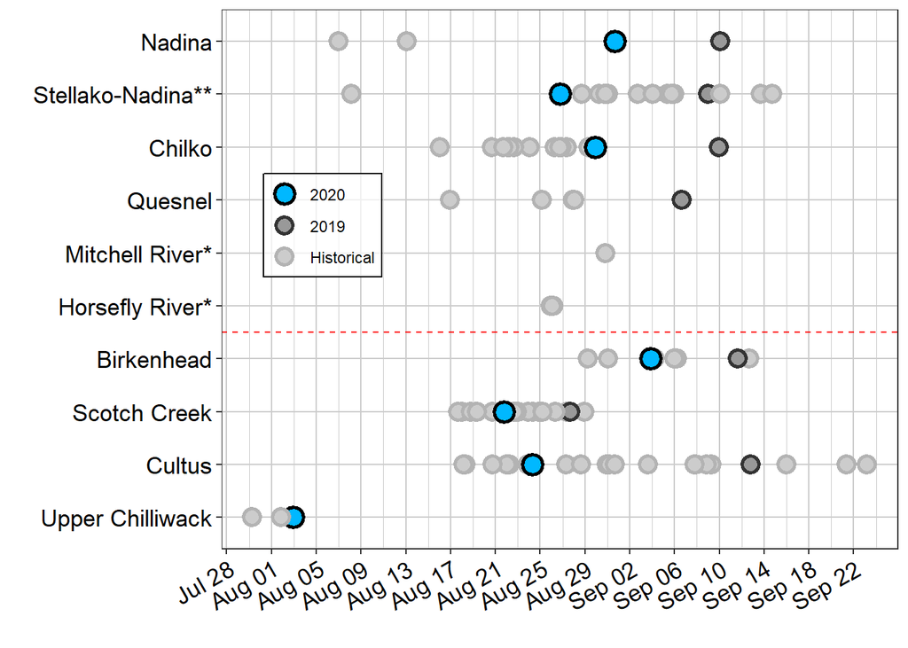

*Fig 1. Arrival dates at which >=10% of the total sockeye escapement passed the fence or SONAR up to and including 2020. *Horsefly River had SONARs in 2006, 2007 and 2010 all with the same 10% date; Mitchell River had a SONAR in 2009. **Stellako-Nadina is an aggregate of both Stellako and Nadina sockeye. Program start dates varied over time. Points are jittered to show multiple years with the same 10% arrival date. Program names are organized from north to south; red line indicates stocks above and below the Big Bar landslide.*

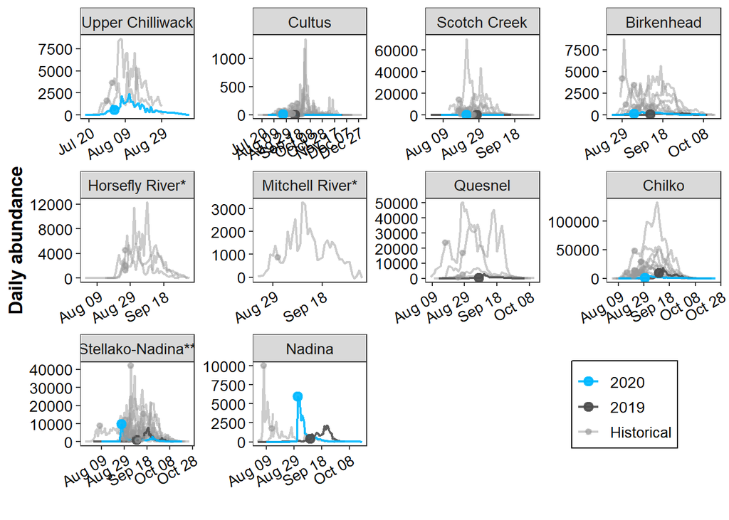

*Fig 2. Migration curves with 10% arrival dates (points) up to 2020. *Horsefly River had SONARs in 2006, 2007 and 2010 all with the same 10% date. Mitchell River had a SONAR in 2009. **Stellako-Nadina is an aggregate of both Stellako and Nadina sockeye; program start dates varied over time.*

## **Peak of spawn**

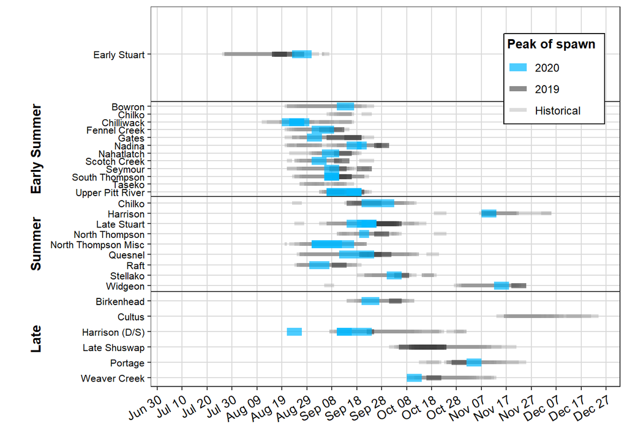

*Figure 3a. Peak of spawn ranges for forecast group stocks from 2000-2020 (2021 not yet included in the DFO escapement database). Years <2000 were omitted due to data quality concerns, but it should be noted that 2000 is an arbitrary break point.*

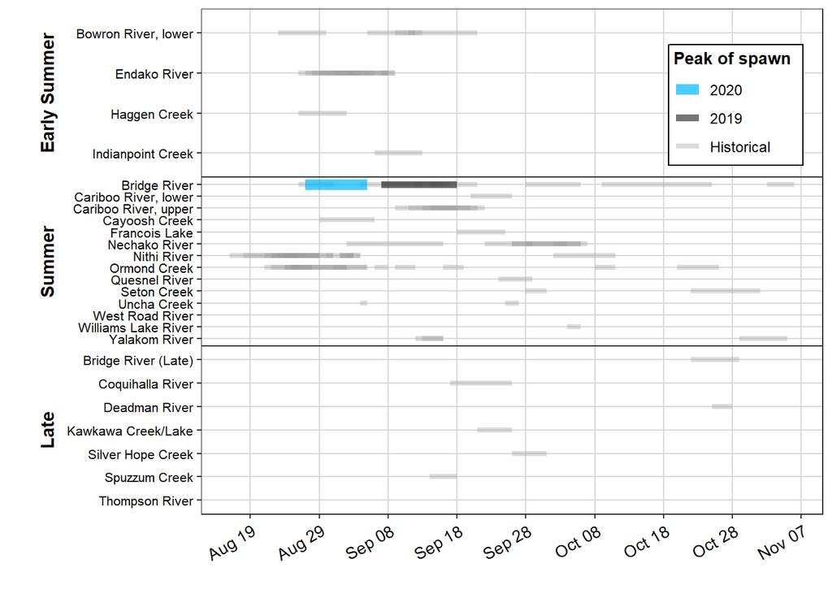

*Figure 3b. Peak of spawn ranges for non-forecast group stocks from 2000-2020 (2021 not yet included in the DFO escapement database). Years <2000 were omitted due to data quality concerns, but it should be noted that 2000 is an arbitrary break point.*

### **Peak of spawn ranges (all forecast stocks)**

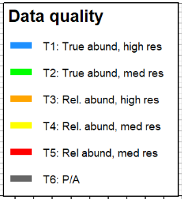

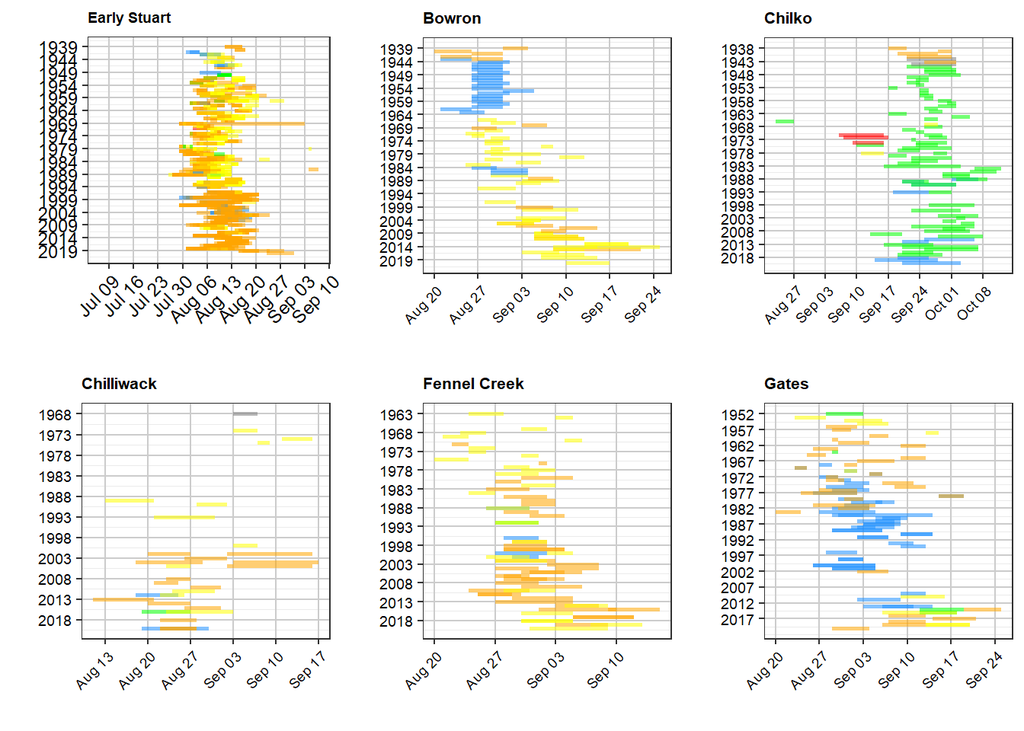

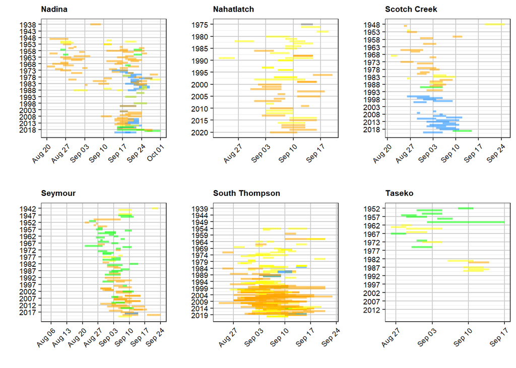

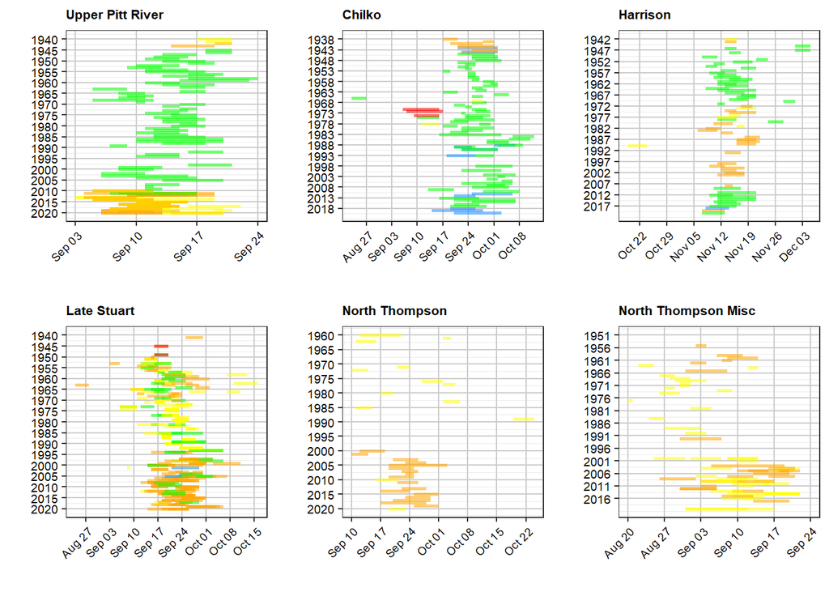

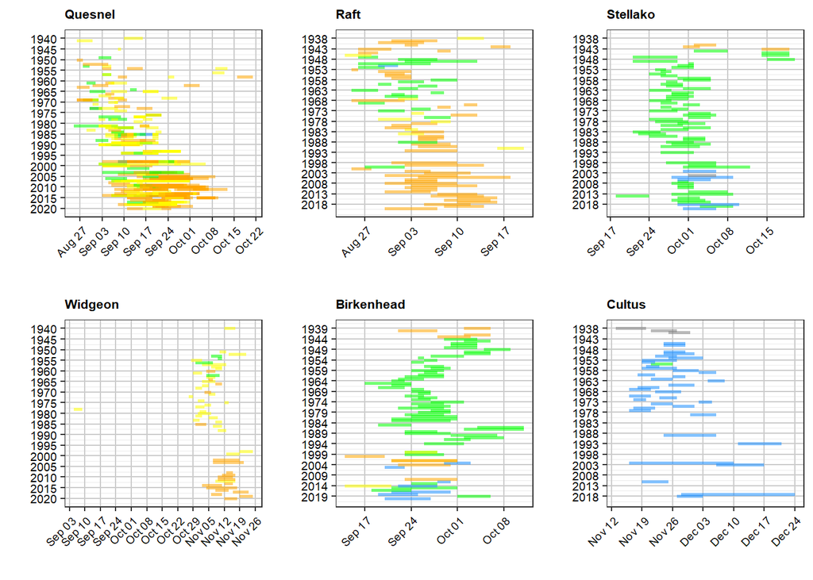

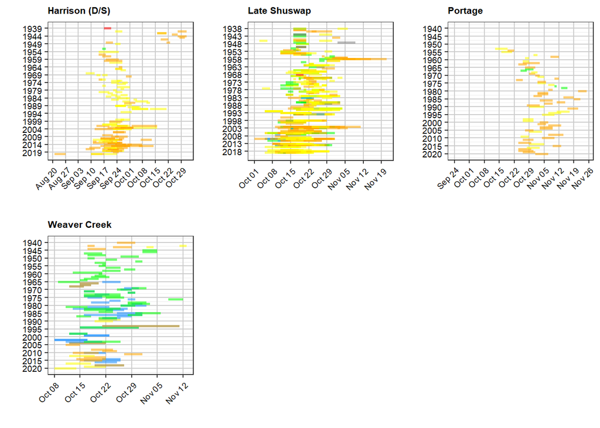

*Figure 4. Peak of spawn ranges for forecast stocks over the entire time series available in the sockeye escapement database up to 2020. Bars are coloured by data quality; larger escapements typically correspond to higher-precision enumeration methods (e.g., T1-T2).*